# FVCOM to Timeseries Demo

- Show All Code
- Hide All Code
- View Source

Processing Regional Timeseries of Surface and Bottom Temperatures

Published

October 27, 2025

```r
####. packages. ####
library(gmRi)           # for building file paths to box
library(tidyverse)      # data wrangling and plotting
library(sf)             # spatial data support
library(rnaturalearth)  # shapefiles for country and states
library(fvcom)          # Bigelow package for dealing with FVCOM
library(ncdf4)          # Support for netcdf files

# Set a plotting theme
theme_set(theme_gmri_simple())

# Project paths on box
lob_ecol_path <- cs_path("mills", "Projects/Lobster ECOL")
fvcom_path    <- cs_path("res", "FVCOM/Lobster-ECOL")
poly_paths    <- cs_path("mills", "Projects/Lobster ECOL/Spatial_Defs")

# State and Province Shapefiles for US + Canada
# Downloaded locally as part of the rnaturalearthhires package
new_england <- ne_states("united states of america", returnclass = "sf") %>%
  filter(postal %in% c("VT", "ME", "RI", "MA", "CT", "NH", "NY", "MD", "VA", "NJ", "DE", "NC", "PA", "WV"))
canada <- ne_states("canada", returnclass = "sf")
```

# Timeseries from FVOM

About:

This is a start-to-finish demo of getting a timeseries from the FVCOM Data using a shapefile.

The FVCOM data I am using as a starting point was prepared for us by Dr. Siqi Li in Dr. Chen’s lab at UMASS Dartmouth. A Key difference between these files (which have a limited number of variables) and a “full” FVCOM file is that there is no dimension for depth.

This difference means that there is one less dimension when indexing data out of these files with square brackets `[]`. This code will need to be modified slighly to index the proper depth (`siglay`) if using another FVCOM file source.

### Load a Shapefile

The following R code will provide the steps to read a shapefile (.shp, .geojson, or similar) into R as a “simple features” dataframe, a special dataframe that contains geospatial information (like the coordinate reference system). These can represent various vector geometries: points, lines, polygons, multipolygons etc.

Then I will plot it just so we can see it.

For this example I will use the lobster management zones:

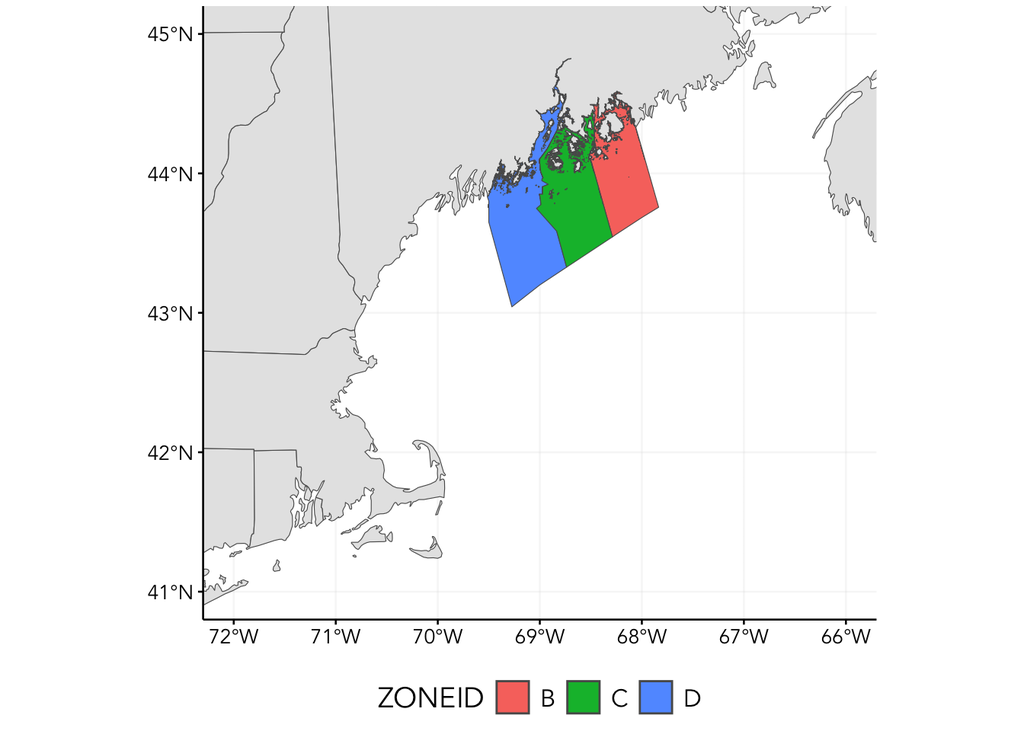

```r
# Make paths
res_shapefiles <- cs_path("res", "Shapefiles")
lob_zones_path <- str_c(res_shapefiles, "LobsterZones/DMR/DMR_Lobster_Zones.shp")

# Read it in
lob_zones <- sf::st_read(lob_zones_path)
# We can subset these objects just like any other dataframe
sf_use_s2(FALSE) # turn off spherical geometry so we can simplify the geometry
lob_zones_main <- filter(lob_zones, ZONEID %in% c("B", "C", "D")) %>%
  st_simplify()

# Plot the subset on a map
ggplot() +
  geom_sf(data = new_england) +
  geom_sf(data = canada) +
  geom_sf(data = lob_zones_main, aes(fill = ZONEID)) +
  coord_sf(xlim = c(-72, -66), ylim = c(41, 45))
```

### Prepare Directory Links to FVCOM

FVCOM Data was delivered via google drive, and then transferred to Box. There is a file with daily data for each year from 1978-2019.

These files are in this directory:  
`Box/Res_Data/FVCOM/Lobster-ECOL/`

For our workflow: we will be opening files sequentially, clipping data for the relevant areas, and returning a dataframe for that period of time. These then get sandwiched together at the end to make one file.

```r
# Here are the files we have, loop over them later
fvcom_surfbot_files <- setNames(
  list.files(fvcom_path, full.names = T, pattern = ".nc"),
  str_remove(list.files(fvcom_path, full.names = F, pattern = ".nc"), ".nc"))
```

### Loading one FVCOM File

```r
# Test File: GOM3 1978
# Load some daily FVCOM that we downloaded and averaged
fvcom_yrx <- nc_open(fvcom_surfbot_files["gom3_1978"])

# The variables we have in each file
names(fvcom_yrx$var)
```

```
 [1] "lon"       "lat"       "nv"        "lonc"      "latc"      "Times"
 [7] "surface_t" "bottom_t"  "surface_u" "surface_v"
```

### Making the FVCOM Mesh into a `sf` object

From the latitude and longitude information in the FVCOM file, we can construct an sf dataframe to represent the mesh spatially on a map. This is helpful for letting us “see” what we’re working with.

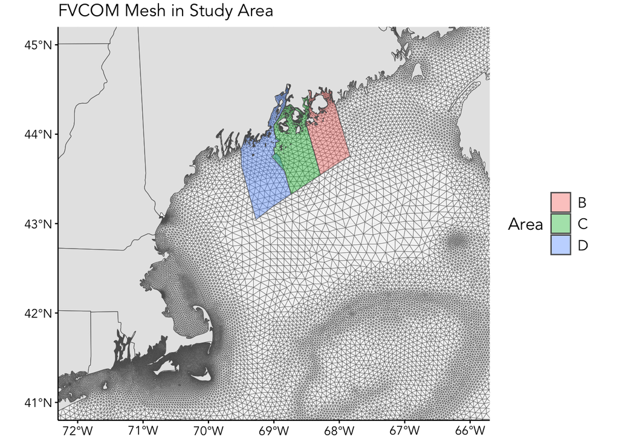

```r
# Get the mesh itself as a simple feature collection
gom3_mesh <- fvcom::get_mesh_geometry(fvcom_yrx, what = 'lonlat')


# Map everything
ggplot() +
  geom_sf(data = gom3_mesh, alpha = 0.4, linewidth = 0.1) +
  geom_sf(data = lob_zones_main, aes(fill = ZONEID), alpha = 0.4) +
  geom_sf(data = new_england) +
  geom_sf(data = canada) +
  theme(legend.position = "right") +
  coord_sf(xlim = c(-72, -66), ylim = c(41, 45)) +
  labs(
    title = "FVCOM Mesh in Study Area",
    fill = "Area")
```

### Using the FVCOM Mesh to Index

Having the FVCOM mesh represented this way also lets us perform geometric operations like spatial intersections, masking, clipping, unions etc.

Because the mesh does not change over the hindcast period, we only need to perform this step once, and then we can use the results as a template for extracting the data from any FVCOM file.

As an extra step, I calculate the area of each mesh triangle within the area we are clipping. I will use this later when averaging the areas as a relative weight.

```r
# There are three zones in "lob_zones_main"
# Then transforms their CRS to match that of the mesh
# For one shapefile just use st_transform(my_shape, crs = st_crs(gom3_mesh))
lobster_zones_trans <- st_transform(lob_zones_main, crs = st_crs(gom3_mesh))


# This code splits them into separate polygons by ZONEID
lobster_zones_trans <- lobster_zones_trans %>%
  split(.$ZONEID)
```

*For Claire*: This is where you would swap in a shapefile you care about. The code below operates on a single shapefile. If you wanted to do it for many shapefiles or a many polygon object you need to add a looping/map step around the code below.

The crop should be by polygon you care about.

If you want to see a demo of doing many at a time see: `FVCOM_Regional_Temperature_Timeseries.qmd`

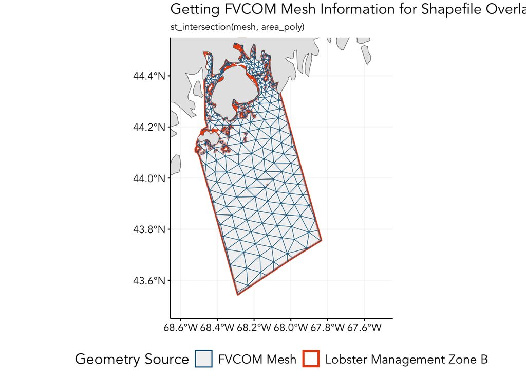

```r
# In this demo I'm using just one, instead of the list
# Use a geomtric intersection to clip the mesh with zone B
crop_b <- st_intersection(
  gom3_mesh,
  # This subsets just zone B from the list
  lobster_zones_trans$B)

# The st_intersection joins the fields from both files based
# returns an object with the shapefile and fvcom fields

# Get areas
# Pull necessary information out: some unique ID, the point and element indexing
# i.e. remove columns that aren't relevant to workflow
crop_b <- crop_b %>%
  mutate(rel_area = st_area(crop_b)) %>%
  select(area_id = ZONEID, elem, p1, p2, p3, rel_area)


# Map what is happening:
ggplot() +
  geom_sf(
    data = lobster_zones_trans$B,
    aes(color = "Lobster Management Zone B"), linewidth = 1,
    fill = "transparent") +
  geom_sf(
    data = crop_b,
    aes(color = "FVCOM Mesh"),
    alpha = 0.5) +
  geom_sf(data = new_england) +
  scale_color_gmri() +
  coord_sf(xlim = c(-68.6, -67.5), ylim = c(43.5, 44.5)) +
  labs(
    title = "Getting FVCOM Mesh Information for Shapefile Overlap",
    subtitle = "st_intersection(mesh, area_poly)",
       color = "Geometry Source")
```

### Use Clipped Mesh as Indexing Key

From this area, we know which nodes to index out by looking at the results of the intersection. The first six rows are shown below (with some columns hidden). We have an information for each `elem` (triangle centers), and the three nodes that go with them (`p1`, `p2`, `p3`)

```r
crop_b %>%
  st_drop_geometry() %>%
  select(area_id , elem, p1, p2, p3, rel_area) %>%
  head() %>%
  gt::gt()
```

| area_id | elem | p1 | p2 | p3 | rel_area |
| --- | --- | --- | --- | --- | --- |
| B | 49775 | 25357 | 25356 | 25065 | 450853.88 [m^2] |
| B | 49776 | 25358 | 25357 | 25065 | 4580520.18 [m^2] |
| B | 49880 | 25412 | 25411 | 25117 | 10368734.30 [m^2] |
| B | 49881 | 25412 | 25117 | 25413 | 20121085.53 [m^2] |
| B | 49882 | 25413 | 25117 | 25118 | 313564.74 [m^2] |
| B | 49883 | 25119 | 25413 | 25118 | 95376.45 [m^2] |

# Get Average Value for Element (triangle area) from values at nodes

For surface and bottom temperatures the values are stored/calculated at the triangle vertices, or nodes.

For regional statistics like the regional average temperature, we need to average the three nodes to get a value representative of the interior space.

This step loops through all the regional elements that are within any of our regions and processes that value once for each. These are then stored in a named list that can be accessed later.

```r
#' @Title FVCOM Element Average from Vertices
#'
#'
#' @description Get the average value from the relevant vertices, along
#' the time dimension for FVCOM mesh triangles.
#'
#' @param mesh_df
#' @param nc
#' @param nc_varname
#'
#' @return
#' @export
#'
#' @examples
regional_from_nodes <- function(fvcom_mesh_trios, nc, nc_varname = "surface_t"){


  # Take the unique elements from our table:
  unique_elems <- distinct(fvcom_mesh_trios, elem) %>% pull(elem)

  # Make a named list
  unique_elems <- setNames(unique_elems, unique_elems)

  # Iterate through each unique element (triangle element, p1, p2, p3)
  # Average the nodes to get value for each element
  triangle_temps <- map(unique_elems, function(elem_id){

    # Slice the row for that element, get distinct in case >1
    elem_df <- filter(fvcom_mesh_trios, elem == elem_id) %>%
      distinct(elem, p1, p2, p3)

    # Get element id
    elem_num <- elem_df[[1, "elem"]]

    # Pull surface_t for the three nodes
    p1_ts <- ncvar_get(
      nc,
      varid = nc_varname,
      start = c(elem_df[[1, "p1"]], 1),
      count = c(1, -1))
    p2_ts <- ncvar_get(
      nc,
      varid = nc_varname,
      start = c(elem_df[[1, "p2"]], 1),
      count = c(1, -1))
    p3_ts <- ncvar_get(
      nc,
      varid = nc_varname,
      start = c(elem_df[[1, "p3"]], 1),
      count = c(1, -1))

    # Get Averages
    elem_avg_var <- (p1_ts + p2_ts + p3_ts) / 3

    # Spit it out, no dataframe bs
    unique_elems[elem_num] <- elem_avg_var

  })

}
```

The function above will take: 1. the dataframe we got from clipping the mesh `crop_b` 2. the open FVCOM file `fvcom_yrx` 3. the name of the variable to subset “surface_t”

And it will return a named list. The names correspond to the `elem` index number i.e. which triangle it is in the mesh. And the values will be the average value from its three nodes for every day.

```r
#  Perform a test on one year
triangle_avg_1978 <- regional_from_nodes(
  fvcom_mesh_trios = crop_b,
  nc = fvcom_yrx,
  nc_varname = "surface_t")
```

# Area-weighted Regional Averages

We now have temperature for each triangle, but we want to get to the average for the entire area. To do this we want to weight them by their surface areas when averaging the many timeseries together.

This will give us the average value for the entire polygon, appropriately weighting each of the component areas.

```r
# Take the code above and calculate the weighted averages:
# function should take:
# 1. region overlay dataframe, containing relative areas for weights
# 2. triangle-specific values


#' @title Regional Averages from FVCOM-Polygon Intersection
#'
#' @description
#'
#' @param mesh_poly_intersection
#' @param regional_means
#' @param nc
#'
#' @return
#' @export
#'
#' @examples
fvcom_regional_averages <- function(mesh_poly_intersection, regional_means, nc){

  # Get the elements
  poly_elems <- as.character(mesh_poly_intersection$elem)

  # pull out the weights, name them
  poly_wts <- as.numeric(mesh_poly_intersection$rel_area) %>%
    setNames(poly_elems)

  # Weight each timeseries by area, then sum them all
  # Get the timeseries that go with the triangles
  # multiply the relevant relative areas
  poly_wtd_ts <- purrr::map(poly_elems, function(x){
    wtd_vals <- regional_means[[x]] * poly_wts[[x]]
    return(wtd_vals)}) %>%
    reduce(.x = ., .f = `+`)

  # Divide by total area
  poly_tot_area <- sum(as.numeric(mesh_poly_intersection$rel_area))

  # Add the time dimension and return as dataframe
  poly_regional <- data.frame(
    "time"     = as.Date(ncvar_get(nc, "Times")),
    "regional_mu" = poly_wtd_ts / poly_tot_area)
  return(poly_regional)

}
```

The output from the above function returns daily data averaged to the shapefile area.

As a test, I’ve run the function on data from 1978 only.

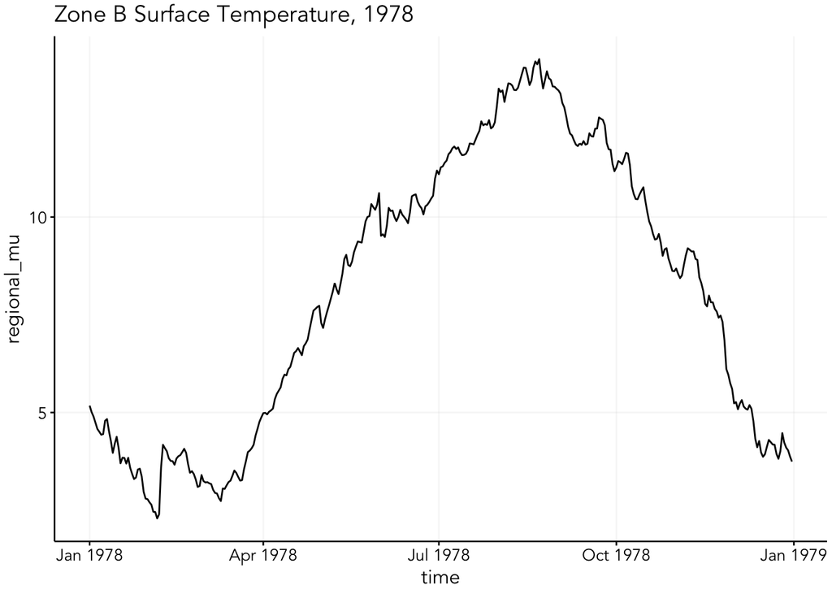

```r
# Run the surface temperatures for 1978
zone_b_surface_t_1978 <- fvcom_regional_averages(
      mesh_poly_intersection = crop_b,
      regional_means = triangle_avg_1978,
      nc = fvcom_yrx)


# Plot the Zone B surface Temperatures
ggplot(zone_b_surface_t_1978) +
  geom_line(aes(time, regional_mu)) +
  labs(title = "Zone B Surface Temperature, 1978")
```

# All together, all years

This is great, but we want data for all the years, not just one.

The good news, is that many of these steps only need to be performed once. The clipping to get the indexing information, and the relative weighting is reusable.

We only really need to loop over the yearly files and extract, then average across mesh elements.

This whole process looks like this:

```r
# Process Surface Temperature for one region:

# Set the fvcom variable here
fvcom_var_name <- "surface_t"
mesh_shape_intersection <- crop_b %>% st_drop_geometry()


# Time it
Sys.time() # Print the start time
```

```
[1] "2025-10-27 15:11:12 EDT"
```

```r
all_year_surface_temp <- map_dfr(
  # Looping through all the fvcom files
  .x = fvcom_surfbot_files,

  # For each one, applying these steps
  .f = function(nc_x){

    # 1. Open the netcdf file for that year:
    yr_x_fvcom <- nc_open(nc_x)

    # 2. Get the average values for the triangles
    # Run that for all the years I guess?!?
    triangle_avgs <- regional_from_nodes(
      fvcom_mesh_trios = mesh_shape_intersection,
      nc = yr_x_fvcom,
      nc_varname = fvcom_var_name)


    # Get the weighted average for the region, from the triangles
    poly_avgs_yr_x <- fvcom_regional_averages(
        mesh_poly_intersection = mesh_shape_intersection,
        regional_means = triangle_avgs,
        nc = yr_x_fvcom)

    # Close the netcdf connection
    nc_close(yr_x_fvcom)

    # Return the regional averages
    return(poly_avgs_yr_x)

})

# print the time on completion
Sys.time()
```

```
[1] "2025-10-27 15:12:19 EDT"
```

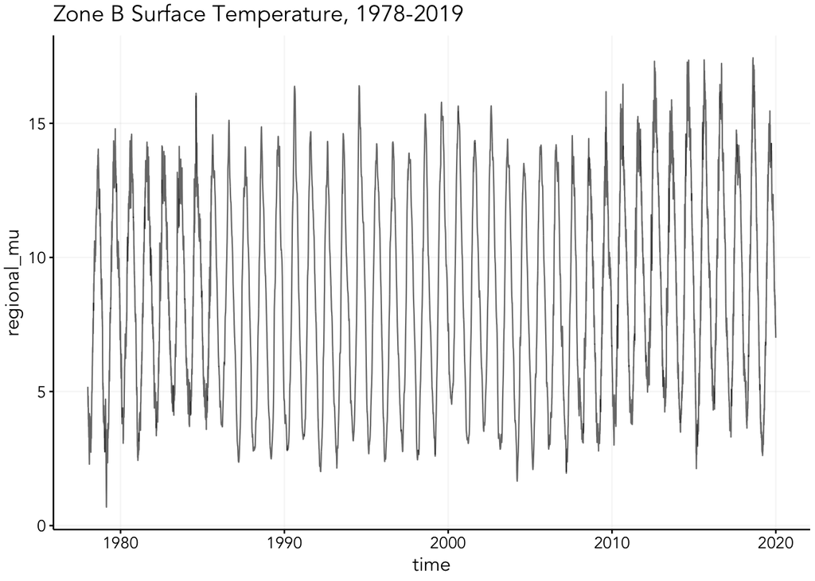

```r
# Plot the data
all_year_surface_temp %>%
  mutate(time = as.Date(time)) %>%
  ggplot() +
  geom_line(
    aes(time, regional_mu),
        linewidth = 0.4, alpha = 0.6) +
  labs(title = "Zone B Surface Temperature, 1978-2019")
```

### Aggregating to Seasonal Values

From here, one could looks more closely at monthly or seasonal averages as desired.

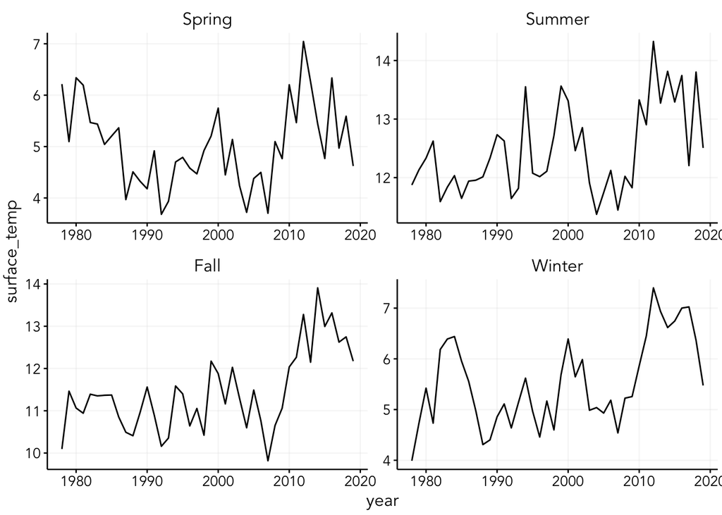

```r
# Aggregate to seasonal averages
seasonal_averages <- all_year_surface_temp %>%
  mutate(
    season = case_when(
      month(time) %in% c(3:5) ~ "Spring",
      month(time) %in% c(6:8) ~ "Summer",
      month(time) %in% c(9:11) ~ "Fall",
      month(time) %in% c(12,1,2) ~ "Winter"),
    season = factor(season, levels = c("Spring", "Summer", "Fall", "Winter"))
  ) %>%
  group_by(year = year(time), season) %>%
  summarise(surface_temp = mean(regional_mu),
            .gorups = "drop")

# Plot the seasons
seasonal_averages %>%
  ggplot(aes(year, surface_temp)) +
  geom_line() +
  facet_wrap(~season, scales = "free")
```

# Bonus Step: